# aesthetics

```python
from ggplot import *
%matplotlib inline
```

### Aesthetics

Aesthetics describe how your data will relate to your plots. Some common aesthetics are: `x`, `y`, and `color`. Aesthetics are specific to the type of plot (or layer) you're adding to your visual. For example, a scatterplot (`geom_point`) and a line (`geom_line`) will share `x` and `y`, but only a line chart has a `linetype` aesthetic.

- `x` : x-axis value. Can be used for continuous (point, line) charts and for discrete (bar, histogram) charts.
- `y` : y-axis value. Can be used for continuous charts only
- `color` : color of a layer. Can be continuous or discrete. If continuous, this will be given a color gradient between 2 colors.
- `shape` : shape of a point. Can be used only with geom_point
- `size` : size of a point or line. Used to give a relative size for a continuous value
- `alpha` : transparency level of a point. Number between 0 and 1. Only supported for hard coded values.
- `ymin` : min value for a vertical line or a range of points. See geom_area, geom_ribbon, geom_vline
- `ymax` : max value for a vertical line or a range of points. See geom_area, geom_ribbon, geom_vline
- `xmin` : min value for a horizonal line. Specific to geom_hline
- `xmax` : max value for a horizonal line. Specific to geom_hline
- `slope` : slope of an abline. Specific to geom_abline
- `intercept` : intercept of an abline. Specific to geom_abline

```python
# set the x-axis equal to the `date` column and the y-axis equal to the `beef` column
my_aes = aes(x='date', y='beef')
my_aes
```

```
{'y': 'beef', 'x': 'date'}
```

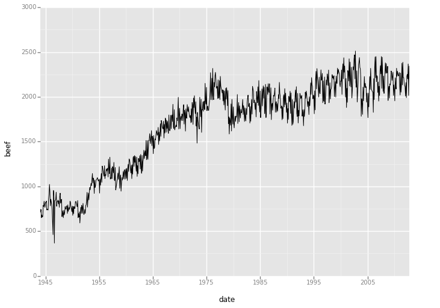

```python
ggplot(meat, my_aes) + geom_line()
```

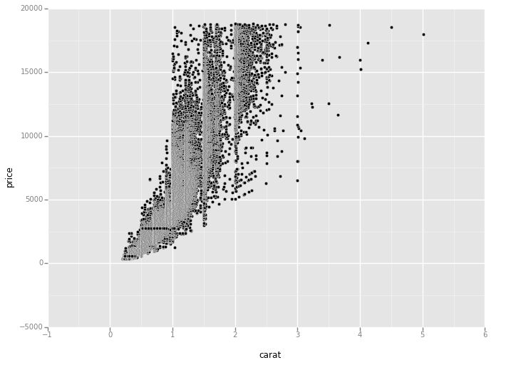

```python
# normally, aes are defined within the `ggplot` constructor
ggplot(aes(x='carat', y='price'), diamonds) + geom_point()
```

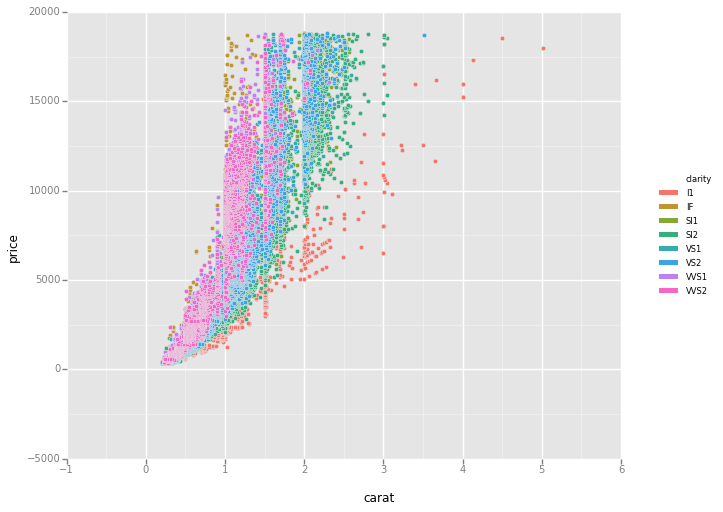

```python
# adding in another aesthetic into the mix...
ggplot(aes(x='carat', y='price', color='clarity'), diamonds) + geom_point()
```